setting up for predictions

```r
fourth_down_data <- data1 %>%
  filter(down == 4)


fourth_down_data <- fourth_down_data %>%
  filter(play_type %in% c("run", "pass")) %>%
  mutate(success = ifelse(yards_gained >= ydstogo, 1, 0))


fourth_down_data <- fourth_down_data %>% filter(!is.na(success))
```

```r
run_data <- fourth_down_data %>%
  filter(play_type == "run")

pass_data <- fourth_down_data %>%
  filter(play_type == "pass")

set.seed(123)
trainIndex_run <- createDataPartition(run_data$success, p = 0.8, list = FALSE)
train_run <- run_data[trainIndex_run, ]
test_run  <- run_data[-trainIndex_run, ]

logistic_run <- glm(success ~ posteam_type + yardline_100 + quarter_seconds_remaining +
                       game_seconds_remaining + game_half_n + ydstogo +
                       no_huddle + run_location_n + run_gap_n + ydsnet,
                     data = train_run,
                     family = binomial)

summary(logistic_run)
```

```
##
## Call:
## glm(formula = success ~ posteam_type + yardline_100 + quarter_seconds_remaining +
##     game_seconds_remaining + game_half_n + ydstogo + no_huddle +
##     run_location_n + run_gap_n + ydsnet, family = binomial, data = train_run)
##
## Coefficients:
##                             Estimate Std. Error z value Pr(>|z|)
## (Intercept)               -1.655e+01  2.400e+03  -0.007 0.994496
## posteam_type              -2.281e-01  2.434e-01  -0.937 0.348733
## yardline_100               3.495e-02  7.568e-03   4.618 3.88e-06 ***
## quarter_seconds_remaining  2.053e-05  5.332e-04   0.038 0.969294
## game_seconds_remaining     2.261e-04  2.846e-04   0.795 0.426892
## game_half_n                4.652e-01  5.969e-01   0.779 0.435707
## ydstogo                   -2.461e-01  6.349e-02  -3.877 0.000106 ***
## no_huddle                  1.593e+01  8.755e+02   0.018 0.985482
## run_location_n             1.548e+01  2.400e+03   0.006 0.994853
## run_gap_n                 -4.330e-01  1.591e-01  -2.721 0.006509 **
## ydsnet                     2.787e-02  6.114e-03   4.558 5.15e-06 ***
## ---
## Signif. codes:  0 '***' 0.001 '**' 0.01 '*' 0.05 '.' 0.1 ' ' 1
##
## (Dispersion parameter for binomial family taken to be 1)
##
##     Null deviance: 484.41  on 373  degrees of freedom
## Residual deviance: 418.61  on 363  degrees of freedom
##   (997 observations deleted due to missingness)
## AIC: 440.61
##
## Number of Fisher Scoring iterations: 15
```

```r
run_preds_prob <- predict(logistic_run, newdata = test_run, type = "response")

run_preds_class <- ifelse(run_preds_prob > 0.6, 1, 0)


cm_run <- confusionMatrix(as.factor(run_preds_class), as.factor(test_run$success))
print(cm_run)
```

```
## Confusion Matrix and Statistics
##
##           Reference
## Prediction  0  1
##          0 12  7
##          1 13 51
##
##                Accuracy : 0.759
##                  95% CI : (0.6527, 0.8462)
##     No Information Rate : 0.6988
##     P-Value [Acc > NIR] : 0.1401
##
##                   Kappa : 0.3856
##
##  Mcnemar's Test P-Value : 0.2636
##
##             Sensitivity : 0.4800
##             Specificity : 0.8793
##          Pos Pred Value : 0.6316
##          Neg Pred Value : 0.7969
##              Prevalence : 0.3012
##          Detection Rate : 0.1446
##    Detection Prevalence : 0.2289
##       Balanced Accuracy : 0.6797
##
##        'Positive' Class : 0
##
```

```r
run_roc <- roc(test_run$success, run_preds_prob)
run_auc <- auc(run_roc)
cat("Run Model AUC:", run_auc, "\n")
```

```
## Run Model AUC: 0.6641379
```

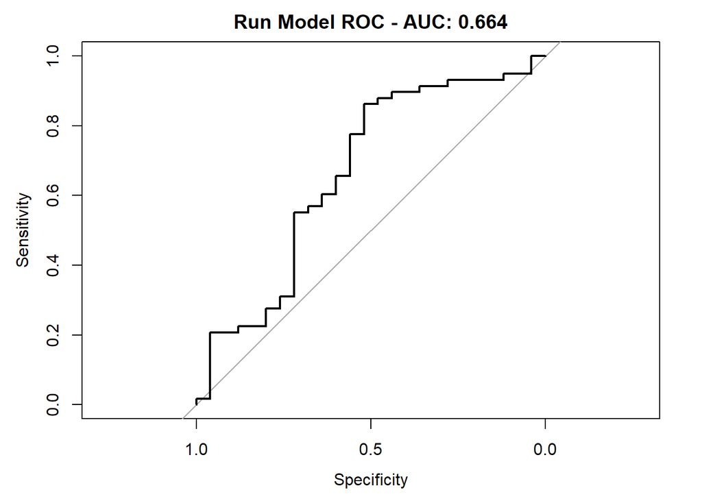

```r
plot(run_roc, main = paste("Run Model ROC - AUC:", round(run_auc, 3)))
```

The logistic regression analysis shows varibles yardline_100, ydstogo, run_gap_n, and ydsnet are statistically significant. The model achieved an accuracy of 75.9%, with a balanced accuracy of 67.97%. The AUC score of 0.664 suggest that it performs slightly better than a random guess and has some predictive capabilities but needs to be improved.

```r
set.seed(123)
trainIndex_pass <- createDataPartition(pass_data$success, p = 0.8, list = FALSE)
train_pass <- pass_data[trainIndex_pass, ]
test_pass  <- pass_data[-trainIndex_pass, ]

logistic_pass <- glm(success ~ posteam_type + yardline_100 + quarter_seconds_remaining +
                        game_seconds_remaining + game_half_n + ydstogo +
                        no_huddle + qb_dropback + qb_scramble +
                        pass_length_n + pass_location_n +ydsnet,
                      data = train_pass,
                      family = binomial)

summary(logistic_pass)
```

```
##
## Call:
## glm(formula = success ~ posteam_type + yardline_100 + quarter_seconds_remaining +
##     game_seconds_remaining + game_half_n + ydstogo + no_huddle +
##     qb_dropback + qb_scramble + pass_length_n + pass_location_n +
##     ydsnet, family = binomial, data = train_pass)
##
## Coefficients: (2 not defined because of singularities)
##                             Estimate Std. Error z value Pr(>|z|)
## (Intercept)               -3.540e+00  8.552e-01  -4.139 3.49e-05 ***
## posteam_type               4.519e-02  1.154e-01   0.392   0.6953
## yardline_100               5.574e-02  4.697e-03  11.869  < 2e-16 ***
## quarter_seconds_remaining  2.270e-04  3.001e-04   0.756   0.4495
## game_seconds_remaining     8.646e-05  1.654e-04   0.523   0.6011
## game_half_n               -1.102e-01  3.454e-01  -0.319   0.7497
## ydstogo                   -9.830e-02  1.489e-02  -6.601 4.09e-11 ***
## no_huddle                 -3.914e-01  2.218e-01  -1.765   0.0776 .
## qb_dropback                       NA         NA      NA       NA
## qb_scramble                       NA         NA      NA       NA
## pass_length_n             -8.685e-01  1.529e-01  -5.681 1.34e-08 ***
## pass_location_n            1.091e-01  1.152e-01   0.947   0.3434
## ydsnet                     6.220e-02  4.350e-03  14.298  < 2e-16 ***
## ---
## Signif. codes:  0 '***' 0.001 '**' 0.01 '*' 0.05 '.' 0.1 ' ' 1
##
## (Dispersion parameter for binomial family taken to be 1)
##
##     Null deviance: 2224.0  on 1622  degrees of freedom
## Residual deviance: 1804.8  on 1612  degrees of freedom
##   (781 observations deleted due to missingness)
## AIC: 1826.8
##
## Number of Fisher Scoring iterations: 4
```

```r
pass_preds_prob <- predict(logistic_pass, newdata = test_pass, type = "response")

pass_preds_class <- ifelse(pass_preds_prob > 0.6, 1, 0)


cm_pass <- confusionMatrix(as.factor(pass_preds_class), as.factor(test_pass$success))
print(cm_pass)
```

```
## Confusion Matrix and Statistics
##
##           Reference
## Prediction   0   1
##          0 212  88
##          1  15  89
##
##                Accuracy : 0.745
##                  95% CI : (0.6996, 0.7869)
##     No Information Rate : 0.5619
##     P-Value [Acc > NIR] : 1.733e-14
##
##                   Kappa : 0.4575
##
##  Mcnemar's Test P-Value : 1.299e-12
##
##             Sensitivity : 0.9339
##             Specificity : 0.5028
##          Pos Pred Value : 0.7067
##          Neg Pred Value : 0.8558
##              Prevalence : 0.5619
##          Detection Rate : 0.5248
##    Detection Prevalence : 0.7426
##       Balanced Accuracy : 0.7184
##
##        'Positive' Class : 0
##
```

```r
pass_roc <- roc(test_pass$success, pass_preds_prob)
pass_auc <- auc(pass_roc)
cat("Pass Model AUC:", pass_auc, "\n")
```

```
## Pass Model AUC: 0.7835685
```

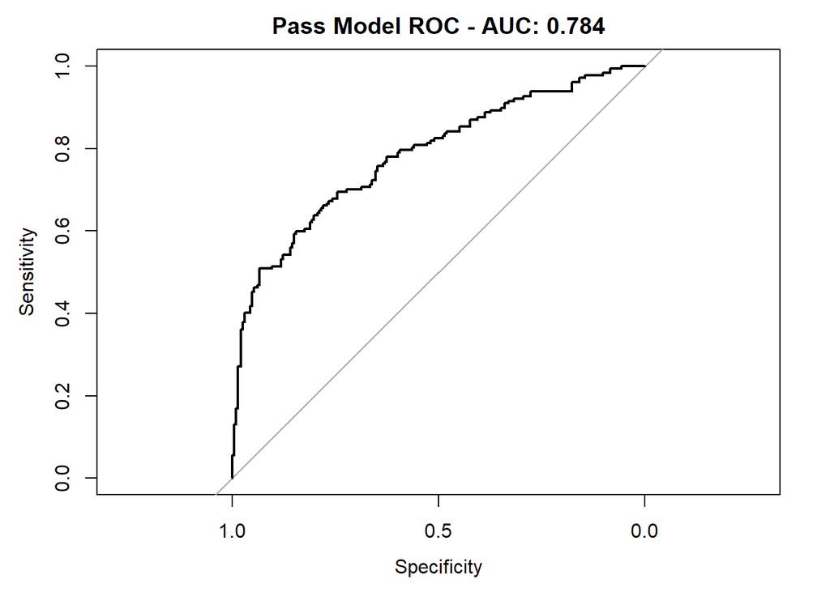

```r
plot(pass_roc, main = paste("Pass Model ROC - AUC:", round(pass_auc, 3)))
```

The logisitic regression on pass plays performed slightly worse with an accuracy of 74.5% but performed significatly better with an auc of 0.784. This shows that its able to distinguish between success and failure with moderate accuracy. The same variables were significant but instead of run gap, pass length was added.

```r
gam_model <- gam(
  success ~ posteam_type + yardline_100 + quarter_seconds_remaining +
    game_seconds_remaining + game_half_n + s(ydstogo) +
    no_huddle + qb_dropback + qb_scramble + pass_length_n + pass_location_n,
  data = train_pass,
  family = binomial(link = "logit")
)

summary(gam_model)
```

```
##
## Family: binomial
## Link function: logit
##
## Formula:
## success ~ posteam_type + yardline_100 + quarter_seconds_remaining +
##     game_seconds_remaining + game_half_n + s(ydstogo) + no_huddle +
##     qb_dropback + qb_scramble + pass_length_n + pass_location_n
##
## Parametric coefficients:
##                             Estimate Std. Error z value Pr(>|z|)
## (Intercept)                0.000e+00  0.000e+00     NaN      NaN
## posteam_type               2.955e-02  1.054e-01   0.280   0.7791
## yardline_100               5.660e-03  2.567e-03   2.205   0.0275 *
## quarter_seconds_remaining  1.937e-04  2.734e-04   0.709   0.4785
## game_seconds_remaining     9.994e-05  1.500e-04   0.666   0.5053
## game_half_n               -7.015e-02  3.139e-01  -0.224   0.8231
## no_huddle                 -3.651e-01  2.087e-01  -1.749   0.0802 .
## qb_dropback                3.323e-01  7.178e-01   0.463   0.6434
## qb_scramble                0.000e+00  0.000e+00     NaN      NaN
## pass_length_n             -7.523e-01  1.363e-01  -5.518 3.43e-08 ***
## pass_location_n            4.327e-02  1.051e-01   0.411   0.6807
## ---
## Signif. codes:  0 '***' 0.001 '**' 0.01 '*' 0.05 '.' 0.1 ' ' 1
##
## Approximate significance of smooth terms:
##            edf Ref.df Chi.sq p-value
## s(ydstogo)   1  1.001  39.51  <2e-16 ***
## ---
## Signif. codes:  0 '***' 0.001 '**' 0.01 '*' 0.05 '.' 0.1 ' ' 1
##
## Rank: 18/20
## R-sq.(adj) =  0.0774   Deviance explained =  6.1%
## UBRE = 0.29904  Scale est. = 1         n = 1623
```

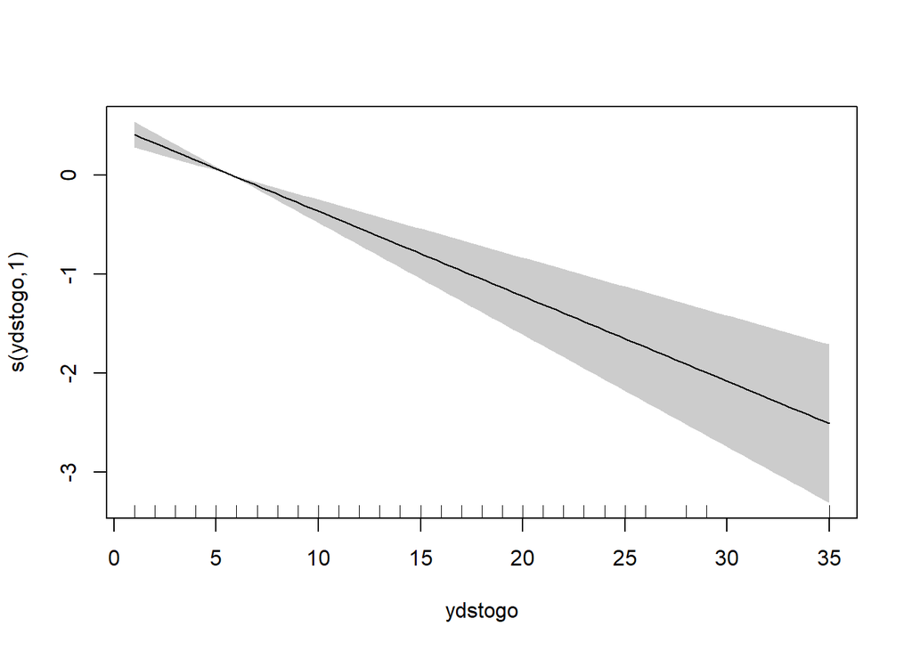

```r
plot(gam_model, shade = TRUE, pages = 1)
```

```r
smoothed_values <- predict(gam_model, newdata = train_pass, type = "terms")

smoothed_data_pass <- data.frame(
  ydstogo = train_pass$ydstogo,
  s_ydstogo = smoothed_values[, "s(ydstogo)"]
)


zero_crossing <- smoothed_data_pass[which.min(abs(smoothed_data_pass$s_ydstogo)), ]
print(zero_crossing)
```

```
##    ydstogo   s_ydstogo
## 38       6 -0.02319572
```

While the model performed poorly in explaining the data it was able to identify that 6 yards seems to be the tipping point where the ydstogo predictor doesn’t affect the pass data. I was curious about this and thought about exploring this more for the future models. Possiblly hold yds to go constant and see how it would impact the results.

```r
gam_model <- gam(
  success ~ posteam_type + yardline_100 + quarter_seconds_remaining +
                       game_seconds_remaining + game_half_n + s(ydstogo) + ydsnet +
                       no_huddle + run_location_n + run_gap_n,
  data = train_run,
  family = binomial(link = "logit")
)

summary(gam_model)
```

```
##
## Family: binomial
## Link function: logit
##
## Formula:
## success ~ posteam_type + yardline_100 + quarter_seconds_remaining +
##     game_seconds_remaining + game_half_n + s(ydstogo) + ydsnet +
##     no_huddle + run_location_n + run_gap_n
##
## Parametric coefficients:
##                             Estimate Std. Error z value Pr(>|z|)
## (Intercept)               -4.336e+01  6.711e+07   0.000  1.00000
## posteam_type              -2.281e-01  2.434e-01  -0.937  0.34873
## yardline_100               3.495e-02  7.568e-03   4.618 3.88e-06 ***
## quarter_seconds_remaining  2.053e-05  5.332e-04   0.038  0.96929
## game_seconds_remaining     2.261e-04  2.846e-04   0.795  0.42689
## game_half_n                4.652e-01  5.969e-01   0.779  0.43571
## ydsnet                     2.787e-02  6.114e-03   4.558 5.15e-06 ***
## no_huddle                  3.893e+01  2.536e+07   0.000  1.00000
## run_location_n             4.179e+01  6.711e+07   0.000  1.00000
## run_gap_n                 -4.330e-01  1.591e-01  -2.721  0.00651 **
## ---
## Signif. codes:  0 '***' 0.001 '**' 0.01 '*' 0.05 '.' 0.1 ' ' 1
##
## Approximate significance of smooth terms:
##            edf Ref.df Chi.sq  p-value
## s(ydstogo)   1      1  15.03 0.000106 ***
## ---
## Signif. codes:  0 '***' 0.001 '**' 0.01 '*' 0.05 '.' 0.1 ' ' 1
##
## R-sq.(adj) =  0.129   Deviance explained = 13.6%
## UBRE = 0.17809  Scale est. = 1         n = 374
```

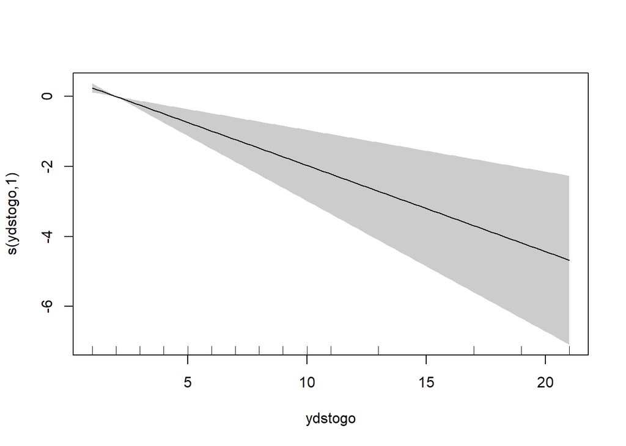

```r
plot(gam_model, shade = TRUE, pages = 1)
```

```r
smoothed_values <- predict(gam_model, newdata = train_run, type = "terms")


smoothed_data_run <- data.frame(
  ydstogo = train_run$ydstogo,
  s_ydstogo = smoothed_values[, "s(ydstogo)"]
)


zero_crossing_run <- smoothed_data_run[which.min(abs(smoothed_data_run$s_ydstogo)), ]
print(zero_crossing_run)
```

```
##    ydstogo    s_ydstogo
## 33       2 2.143929e-06
```

This model also performed poorly but similar to the last model I was able to determine 2 yards seems to be the tipping point where the ydstogo predictor doesn’t affect the data.

```r
set.seed(123)
trainIndex_run <- createDataPartition(run_data$success, p = 0.8, list = FALSE)
train_run <- run_data[trainIndex_run, ]
test_run <- run_data[-trainIndex_run, ]


train_run$success <- factor(train_run$success, levels = c("0", "1"))
test_run$success <- factor(test_run$success, levels = c("0", "1"))


train_run$run_location_n[is.na(train_run$run_location_n)] <- "Unknown"
train_run$run_gap_n[is.na(train_run$run_gap_n)] <- "Unknown"
test_run$run_location_n[is.na(test_run$run_location_n)] <- "Unknown"
test_run$run_gap_n[is.na(test_run$run_gap_n)] <- "Unknown"


train_run$run_location_n <- factor(train_run$run_location_n)
train_run$run_gap_n <- factor(train_run$run_gap_n)
test_run$run_location_n <- factor(test_run$run_location_n)
test_run$run_gap_n <- factor(test_run$run_gap_n)


train_run <- train_run[!is.na(train_run$game_half_n), ]



rf_run <- randomForest(
  success ~ posteam_type + yardline_100 + quarter_seconds_remaining +
    game_seconds_remaining + game_half_n + ydstogo + ydsnet +
    no_huddle + run_location_n + run_gap_n,
  data = train_run,
  ntree = 400,
  mtry = 9,
  importance = TRUE
)


rf_run_preds <- predict(rf_run, newdata = test_run)


conf_matrix <- confusionMatrix(rf_run_preds, test_run$success)
print(conf_matrix)
```

```
## Confusion Matrix and Statistics
##
##           Reference
## Prediction   0   1
##          0  60  25
##          1  72 180
##
##                Accuracy : 0.7122
##                  95% CI : (0.6606, 0.7599)
##     No Information Rate : 0.6083
##     P-Value [Acc > NIR] : 4.373e-05
##
##                   Kappa : 0.3551
##
##  Mcnemar's Test P-Value : 3.003e-06
##
##             Sensitivity : 0.4545
##             Specificity : 0.8780
##          Pos Pred Value : 0.7059
##          Neg Pred Value : 0.7143
##              Prevalence : 0.3917
##          Detection Rate : 0.1780
##    Detection Prevalence : 0.2522
##       Balanced Accuracy : 0.6663
##
##        'Positive' Class : 0
##
```